# Chapter 9 - clustering: exercises

Author

Prof. Richard Wilkinson

## Question 1

Consider the data points

$$\mathbf x_1 =\begin{pmatrix}10\\5\end{pmatrix}, \quad
\mathbf x_2 =\begin{pmatrix}7\\3\end{pmatrix}, \quad \mathbf x_3 =\begin{pmatrix}4\\8\end{pmatrix}, \quad
\mathbf x_4 =\begin{pmatrix}5\\12\end{pmatrix}$$

Starting with the encoder
$$\boldsymbol \delta= \begin{pmatrix} 1\\2\\1\\2\end{pmatrix}$$
implement (by hand) the K-means cluster greedy optimization algorithm until convergence (with 2 clusters).

**Solution**

We iterate through the following steps until convergence.

- Estimate the cluster means $\hat{\mu}_1$ and $\hat{\mu}_2$ given $\delta$
- For the given cluster means, allocate each point to its closest cluster centre, i.e., set
  $$\delta(i) = \arg\min_k ||\mathbf x_i - \hat{\mu}_k||^2.$$

**First iteration**: With encoder
$$\boldsymbol \delta= \begin{pmatrix} 1\\2\\1\\2\end{pmatrix}$$
we get cluster means
$$\hat{\mu}_1 = \frac{1}{2}\left(\begin{pmatrix}10\\5\end{pmatrix}+ \begin{pmatrix}4\\8\end{pmatrix} \right)=\begin{pmatrix}7\\6.5\end{pmatrix}
\qquad \hat{\mu}_2 = \frac{1}{2}\left(\begin{pmatrix}7\\3\end{pmatrix}+ \begin{pmatrix}5\\12\end{pmatrix} \right)=\begin{pmatrix}6\\7.5\end{pmatrix}$$
Allocating each point to its closest cluster mean gives
$$\boldsymbol \delta= \begin{pmatrix} 1\\1\\2\\2\end{pmatrix}$$
**Second iteration**: We get cluster means
$$\hat{\mu}_1 = \frac{1}{2}\left(\begin{pmatrix}10\\5\end{pmatrix}+ \begin{pmatrix}7\\3\end{pmatrix} \right)=\begin{pmatrix}8.5\\4\end{pmatrix}
\qquad \hat{\mu}_2 = \frac{1}{2}\left(\begin{pmatrix}4\\8\end{pmatrix}+ \begin{pmatrix}5\\12\end{pmatrix} \right)=\begin{pmatrix}4.5\\10\end{pmatrix}$$

Allocating each point to its closest cluster mean again gives
$$\boldsymbol \delta= \begin{pmatrix} 1\\1\\2\\2\end{pmatrix}$$
and so we can see that we have converged after just 2 iterations.

## Question 2

In the table below, information is given on the presence or absence (denoted by $1$ and $0$, respectively) of $6$ unspecified attributes, denoted A1, …, A6, in Lions, Giraffes, Sheep and Humans.
$$\begin{array}{cccccccc}
\textrm{Individual} &&\textrm{A1}&\textrm{A2}&\textrm{A3}&\textrm{A4}&\textrm{A5}&\textrm{A6}\\
&&&&&&\\
\textrm{Lion}&&1&1&0&0&1&1\\
\textrm{Giraffe}&&1&1&1&0&0&1\\
\textrm{Sheep}&&1&0&0&1&0&1\\
\textrm{Human}&&0&0&0&0&1&0
\end{array}$$

1. Use the information in the table to calculate a similarity matrix based on the simple matching coefficient.

**Solution**

You should do this by hand, but the answer is

```
         lion giraffe sheep human
lion    1.000   0.667 0.500 0.500
giraffe 0.667   1.000 0.500 0.167
sheep   0.500   0.500 1.000 0.333
human   0.500   0.167 0.333 1.000
```

2. Using a suitable transformation, convert the similarity matrix into a dissimilarity matrix, $\mathbf D$ say.

**Solution**

You can do this as we did in the chapter on MDS
$$d_{ij}=\left ( f_{ii}+f_{jj} -2f_{ij} \right )^{1/2}$$
which gives

```
         lion giraffe sheep
giraffe 0.816
sheep   1.000   1.000
human   1.000   1.290 1.150
```

You can also just do 1-SMC, but that results in a different distance function.

3. Apply the single linkage method to the matrix $\mathbf D$. Summarise your results graphically in a dendrogram.

**Solution**

The ordering of the distances is given by
$$d_{LG}< d_{LS}=d_{LH} = d_{GS}<d_{SH}<d_{GH}.$$

So the sequence of clusters given by single linkage is

- Stage 0: clusters are $\{\text{L}\}$, $\{\text{G}\}$, $\{\text{S}\}$ and $\{\text{H}\}$.
- Stage 1: qw join the clusters $\{L\}$ and $\{G\}$ at distance 0.816 giving new clusters $\{\text{L}, \text{G}\}$, $\{\text{S}\}$ and $\{\text{H}\}$ and new distance matrix is

```
    LG    S
S 1.00
H 1.00 1.15
```

- Stage 2: we have a tie, so we join LG with S and H (at distance 1.0), giving the clusters $\{\text{L}, \text{G}, \text{S}, \text{H}\}$.

The dendrogram is as follows

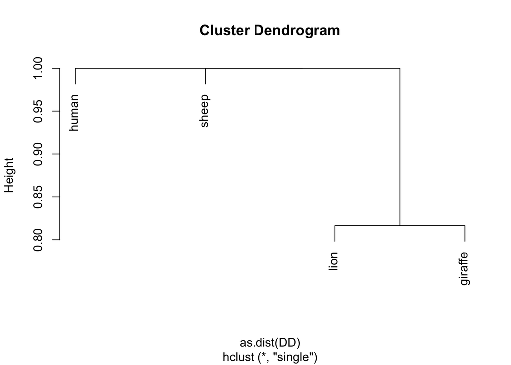

4. Apply the complete linkage method to the matrix $\mathbf D$. Summarise your results graphically in a dendrogram.

**Solution**

The first two stages are the same as for single linkage:

- Stage $0^\prime$: clusters are $\{\text{L}\}$, $\{\text{G}\}$, $\{\text{S}\}$ and $\{\text{H}\}$. and the distance matrix is

```
         lion giraffe sheep
giraffe 0.816
sheep   1.000   1.000
human   1.000   1.290 1.150
```

- Stage $1^\prime$: we join L and G (at distance 0.816), giving clusters $\{\text{L}, \text{G}\}$, $\{\text{S}\}$ and $\{\text{H}\}$. The new distance matrix between clusters is

```
    LG    S
S 1.00
H 1.29 1.15
```

as
$$d^\ast_C(\{L,G\}, \{S\})=\max (d_{LS}, d_{GS})=1,$$
$$d_C^\ast (\{L,G\}, \{H\})=\max (d_{LH},d_{GH})=1.2910$$

- Stage $2^\prime$: we join LG and S at distance 1, giving clusters $\{\text{L}, \text{G}, \text{S}\}$ and $\{\text{H}\}$. The new distance matrix is

```
   LGS
H 1.29
```

The dendrogram is

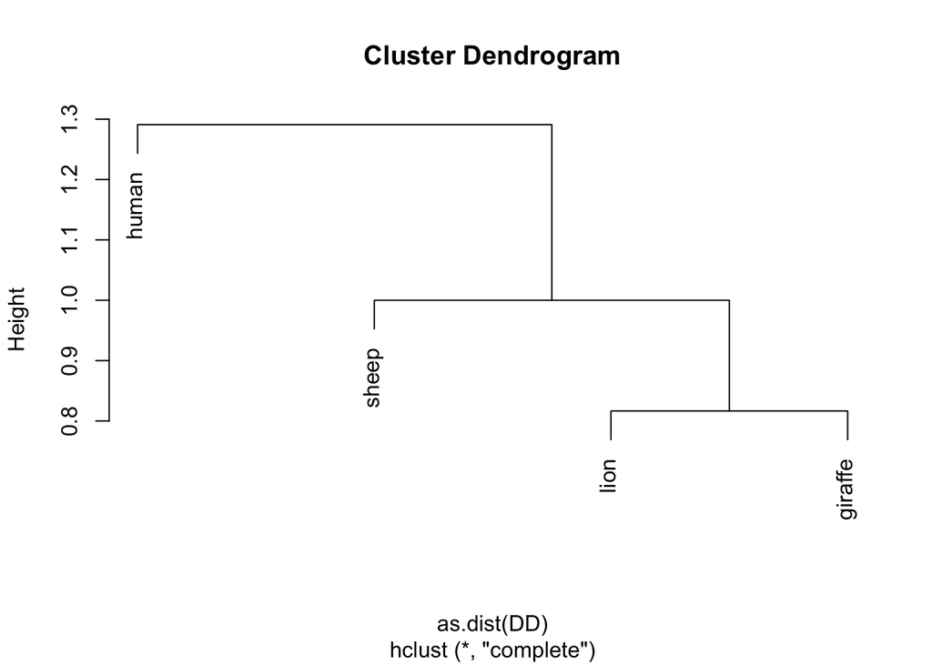

22. Suppose exactly two clusters are required. What would be your clusters based on single linkage and complete linkage?

**Solution**

If we settle on precisely two clusters then complete linkage suggests $\{$L,G,S$\}$ and $\{$H$\}$. Single linkage cannot be used to create two clusters without a tie-breaking rule.

6. Repeat part v., but this time with three clusters rather than two.

**Solution**

If we decide on three clusters, both single linkage and complete linkage suggest the following three clusters: $\{$L,G$\}$, $\{$S$\}$ and $\{$H$\}$.

7. Briefly (i.e. in one or two sentences) summarise your findings.

**Solution**

In this example the single linkage and complete linkage approaches give similar (but not identical) results.

## Question 3

Attempt question 4b from the 2017-18 exam paper.

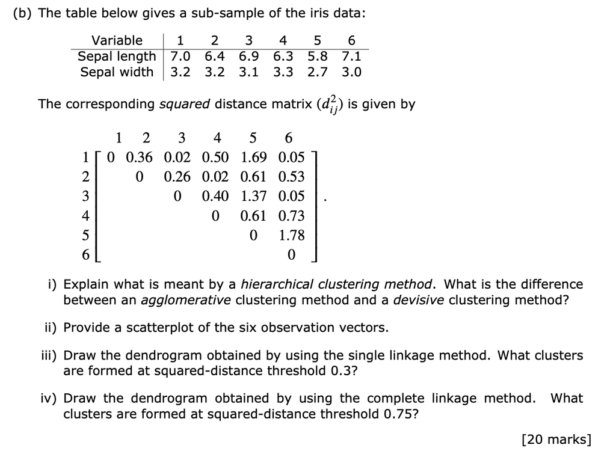

**Solution**

1. Hierarchical clustering methods work by creating a hierarchy of clusters, in which clusters at each level of the heirarchy are formed by merging or splitting clusters from a neighbouring level of the hierarchy.
- agglomerative clustering methods start with the finest partition (one observation per cluster) and progressively combine clusters.
- divisive/splitting clustering methods start with a single cluster, and then progressively splits or divides clusters.

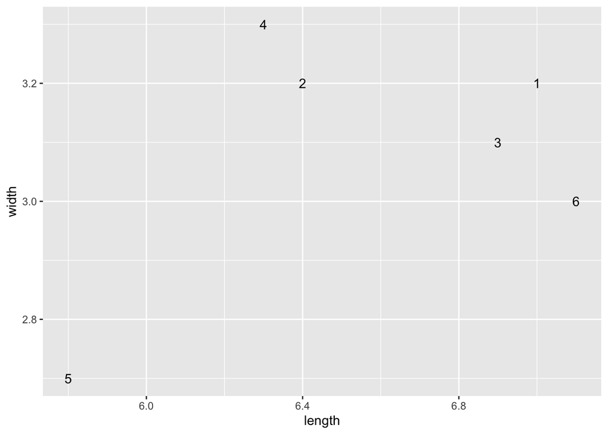

3. We’ll go through the calculation by hand during the lecture.

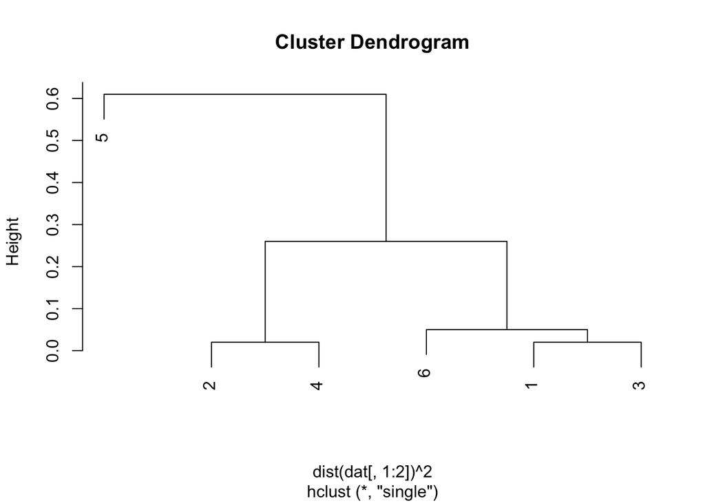

```r
D.sl <-hclust(dist(dat[,1:2])^2, method="single")
plot(D.sl)
```

```r
cutree(D.sl,h = 0.3)
```

```
[1] 1 1 1 1 2 1
```

So at threshold 0.3 we have clusteres $\{1,2,3,4,6\}$ and $\{5\}$.

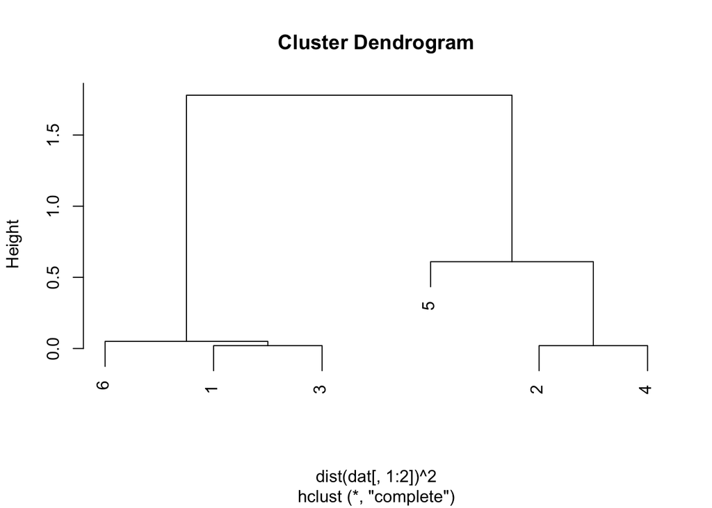

```r
D.sl <-hclust(dist(dat[,1:2])^2, method="complete")
plot(D.sl)
```

```r
cutree(D.sl,h = 0.75)
```

```
[1] 1 2 1 2 2 1
```

## Question 4

Prove Equation 9.2, namely that the within-cluster scatter reduces to
$$\begin{align}
W(\delta) &= \frac{1}{2}\sum_{k=1}^K \sum_{i: \delta(i)=k} \sum_{i': \delta(i')=k} ||\mathbf x_i - \mathbf x_{i'}||_2^2 \\
&= \sum_{k=1}^K n_k \sum_{i: \delta(i)=k} ||\mathbf x_{i} - \hat{{\boldsymbol{\mu}}}_k||_2^2
\end{align}$$

**Solution**

To prove this we just need to show that for $\mathbf x_1, \ldots, \mathbf x_n$ we have

$$\sum_{i}\sum_{j} ||\mathbf x_i-\mathbf x_j||^2=2n \sum_i ||\mathbf x_i- \hat{\mu}||^2$$

Starting with the LHS
$$\begin{align*}
\sum_{i}\sum_{j} ||\mathbf x_i-\mathbf x_j||^2&=\sum_{i}\sum_{j} ||(\mathbf x_i-\hat{\mu}) + (\hat{\mu}-\mathbf x_j)||^2\\
&=\sum_{i}\sum_{j} ||\mathbf x_i - \hat{\mu}||^2 -2(\mathbf x_i - \hat{\mu})^\top (\mathbf x_j - \hat{\mu}) + ||\mathbf x_j - \hat{\mu}||^2\\
&=2n\sum_{i} ||\mathbf x_i - \hat{\mu}||^2
\end{align*}$$
as required.